# Final Report about Prediction Sale Price of houses in Iowa

#### It was the good start because I got 86 % of R-squared, which mean my model explained 86% of data. However, I still wanted to improve my r-squared to make the best model, which has lowest number of predictors with high r-squared.

```r
step(m1, direction = "backward", data=train)
```

[output not shown]

```r
#new model with predictors which have the lowest AIC
m2 <- lm(SalePrice~LotArea+OverallQual+OverallCond +YearRemodAdd + MasVnrArea + BsmtFinSF1+TotalBsmtSF+X1stFlrSF+X2ndFlrSF+BsmtFullBath+Fireplaces+GarageArea+Neighborhood+Exterior1st+LandContour+LotConfig+GarageYrBlt+BldgType+HouseStyle+RoofMatl+ExterQual+SaleCondition,data=train)
#summary(m2)
summary(lm(m2,train))$r.squared #r squared
```

```
## [1] 0.9141743
```

#### I used step function to reduce the number of predictors. The step function shows AIC, so I can easiliy choose the best predictors with the lowest AIC. Frome the result of step function which has the lowest AIC, I reduced some predictors and made second draft model m2. I checked my r-squared got improved to 91%.

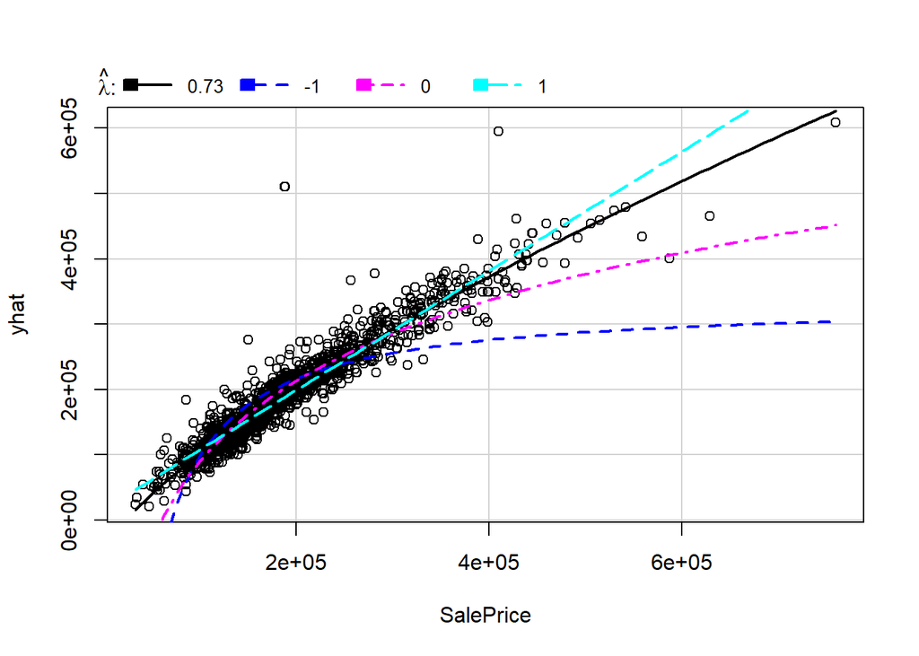

```r
#find lambda for trasformation
inverseResponsePlot(m2)
```

#### I needed to check the validity of my model. Since my RSE of my model is super high, I wanted to transform with the best lambda to check the plot. By use of inverseresponseplot function, I got the best lambda .73.

[figure not shown]

```r
par(mfrow=c(2,2))
plot(m2)
```

```r
#check vif
v<-vif(m2)
vif.table <- data.frame((v[,3]))
vif.table
```

```
##               X.v...3..
## LotArea        1.251140
## OverallQual    2.101429
## OverallCond    1.266244
## YearRemodAdd   1.671926
## MasVnrArea     1.353914
## BsmtFinSF1     1.630466
## TotalBsmtSF    2.121818
## X1stFlrSF      2.319026
## X2ndFlrSF      2.767636
## BsmtFullBath   1.404107
## Fireplaces     1.321299
## GarageArea     1.768816
## Neighborhood   1.135574
## Exterior1st    1.109606
## LandContour    1.147567
## LotConfig      1.043953
## GarageYrBlt    1.387264
## BldgType       1.244240
## HouseStyle     1.256765
## RoofMatl       1.064921
## ExterQual      1.347054
## SaleCondition  1.093317
```

```r
anova<- anova(m2)
anova
```

```r
od<-order(anova[,"Pr(>F)"], decreasing = TRUE)
anova[od,]
```

```
## Analysis of Variance Table
##
## Response: (SalePrice)^0.73
##                 Df     Sum Sq    Mean Sq    F value    Pr(>F)
## GarageYrBlt      1    5565349    5565349    16.3705 5.373e-05 ***
## LotConfig        4    9437913    2359478     6.9404 1.493e-05 ***
## SaleCondition    5   11098776    2219755     6.5294 4.842e-06 ***
## Fireplaces       1   11186741   11186741    32.9058 1.088e-08 ***
## HouseStyle       7   21978786    3139827     9.2358 2.541e-11 ***
## Exterior1st     14   28640762    2045769     6.0176 7.776e-12 ***
## BsmtFullBath     1   24268941   24268941    71.3872 < 2.2e-16 ***
## LandContour      3   29245616    9748539    28.6754 < 2.2e-16 ***
## OverallCond      1   34291969   34291969   100.8700 < 2.2e-16 ***
## ExterQual        3   40736431   13578810    39.9421 < 2.2e-16 ***
## BldgType         4   53464637   13366159    39.3166 < 2.2e-16 ***
## YearRemodAdd     1   90224133   90224133   265.3947 < 2.2e-16 ***
## GarageArea       1  116714211  116714211   343.3154 < 2.2e-16 ***
## TotalBsmtSF      1  128516688  128516688   378.0324 < 2.2e-16 ***
## X1stFlrSF        1  130650676  130650676   384.3095 < 2.2e-16 ***
## RoofMatl         5  161882264   32376453    95.2355 < 2.2e-16 ***
## Neighborhood    24  244811941   10200498    30.0048 < 2.2e-16 ***
## MasVnrArea       1  210278721  210278721   618.5358 < 2.2e-16 ***
## BsmtFinSF1       1  298973056  298973056   879.4305 < 2.2e-16 ***
## X2ndFlrSF        1  415713475  415713475  1222.8230 < 2.2e-16 ***
## LotArea          1  662774376  662774376  1949.5537 < 2.2e-16 ***
## OverallQual      1 7113044479 7113044479 20923.0508 < 2.2e-16 ***
## Residuals     2414  820668529     339962
## ---
## Signif. codes:  0 '***' 0.001 '**' 0.01 '*' 0.05 '.' 0.1 ' ' 1
```

```r
#summary(m2)
summary(lm(m2,train))$r.squared
```

```
## [1] 0.9230443
```

```r
prediction <- predict(m2, test)
summary(prediction)

prediction <- prediction^(1/0.73)
prediction <- data.frame(Ob = 1:1500, SalePrice = prediction)
```

#### By using of predict function I could predict the saleprice of test data set. Since used transformed model, I retransformed the result to make the price normal.

# 4. Results.

#### I was able to reduce the number of predictors from 82 to 22, and got a 92% of r-squared. I made a submission on Kaggle, and it calculated my testing r-squared of 92%. Since the professor’s threshold for r-squared is 83%, I conclude that I made a very good result. In the other word my model has 92% accuracy.

# 5. Discussion.

#### Not all of the 82 variables of Train data set is important to predict the sale price because there are a few variables have correlation with sale price. In other words, there are significant variables and insignificant variables. My final model has 22 variables, that correlate with sale price, and I got 92% r-squared or 92% accuracy. Also the testing r-squared of 92% means my final model explains 92% of variability of the response data around its mean. By checking VIF, my variables are not violating multicorrinearlity. The checking if there is a multicorrinearlity between selected variables is the most important requirement for the model.

# 6.Limitations and Conclusion

#### I used only 22 variables to predict new pirce. This reduction makes program runs faster and efficiently better for the buyer. Although my final model got 92% of high r-squared number, the model is not the perfect model because it still has 8% of error. To make the better model I will be needed to delete all of the bad leverage or find other best combination of predictors or use other classification techniques like randomforest, knn, gradient boosting. Next quarter, I will may be able to make this model much better.

#### I recommend the buyer use my final model to predict the sale price because 92% accuracy is high enought to use. If a buyer uses my final model for his investment, he would be able to recognize which houses are undervalued or which houses are overpriced.

# 7.Reference.

#### Nau Robert. “Statistical Forecasting: notes on regression and time series analysis”. https://people.duke.edu/~rnau/411home.htm.

#### Kaggle. “Predicting Sale Price of Houses in Iowa”. https://www.kaggle.com/c/stat101ahouseprice.

#### Epidemiol J Nepal. “Understanding Significance and P-Values”, 2016 Mar. https://www.ncbi.nlm.nih.gov/pmc/articles/PMC4850233/